# business_failure

## Business Understanding

The failure rate of startups remains a significant concern for entrepreneurs, investors, and the business community alike. While some startups thrive and achieve substantial financial success through M&A or IPO events, a substantial number of others face closure and subsequent failure. Understanding the underlying reasons behind startup failures is crucial for stakeholders in the business ecosystem to make informed decisions, mitigate risks, and enhance the prospects of success.

The primary objective of this analysis is to identify and analyze the key factors that contribute to the success or failure of startups based on a set of relevant features and historical data. By gaining comprehensive insights into these factors, we aim to provide actionable recommendations and strategies that can help mitigate potential risks and improve the likelihood of startup success.

Key Questions;

- How Many New Businesses Fail ?
- How Many New Businesses Succeed ?
- Reasons for Failing
- How to Avoid Failing

## Data Understanding

The CrunchBase Dataset, accessible through [Kaggle](https://www.kaggle.com/datasets/yanmaksi/big-startup-secsees-fail-dataset-from-crunchbase), provides a valuable resource for data scientists working on understanding the dynamics of startup failures. With a comprehensive compilation of companies, their detailed information, and a breakdown of their funding rounds and individual investments, this dataset holds immense potential for gaining insights into the factors that contribute to business startup failures. By analyzing this data, we aim to uncover patterns, trends, and key indicators that can assist venture capital firms and entrepreneurs in making informed decisions, mitigating risks, and fostering successful ventures in the dynamic world of startups.

### Snapshot of dataset

```
Rows: 66,368
Columns: 14
$ permalink         <chr> "/organization/-fame", "/organization/-qounter", "/o…
$ name              <chr> "#fame", ":Qounter", "(THE) ONE of THEM,Inc.", "0-6.…
$ homepage_url      <chr> "http://livfame.com", "http://www.qounter.com", "htt…
$ category_list     <chr> "Media", "Application Platforms|Real Time|Social Net…
$ funding_total_usd <dbl> 10000000, 700000, 3406878, 2000000, 0, 41250, 762851…
$ status            <chr> "operating", "operating", "operating", "operating", …
$ country_code      <chr> "IND", "USA", "", "CHN", "USA", "HKG", "CAN", "USA",…
$ state_code        <chr> "16", "DE", "", "22", "IL", "", "BC", "CA", "CA", "1…
$ region            <chr> "Mumbai", "DE - Other", "", "Beijing", "Springfield,…
$ city              <chr> "Mumbai", "Delaware City", "", "Beijing", "Champaign…
$ funding_rounds    <int> 1, 2, 1, 1, 1, 1, 2, 4, 3, 1, 1, 1, 1, 1, 1, 1, 1, 4…
$ founded_at        <date> NA, 2014-09-04, NA, 2007-01-01, 2010-01-01, NA, 199…
$ first_funding_at  <date> 2015-01-05, 2014-03-01, 2014-01-30, 2008-03-19, 201…
$ last_funding_at   <date> 2015-01-05, 2014-10-14, 2014-01-30, 2008-03-19, 201…
```

| Variable Name | Data Type | Data Points (Count) | Missing Data (Count) | Missing Data (%) | Unique Values |
| --- | --- | --- | --- | --- | --- |
| permalink | character | 66,368 | 0 | 0.0% | 66,368 |
| name | character | 66,368 | 0 | 0.0% | 66,103 |
| homepage_url | character | 61,310 | 5,058 | 7.6% | 61,192 |
| category_list | character | 66,368 | 0 | 0.0% | 27,297 |
| funding_total_usd | numeric | 66,368 | 0 | 0.0% | 18,896 |
| status | character | 66,368 | 0 | 0.0% | 4 |
| country_code | character | 59,410 | 6,958 | 10.5% | 138 |
| state_code | character | 57,821 | 8,547 | 12.9% | 312 |
| region | character | 58,338 | 8,030 | 12.1% | 1,093 |
| city | character | 58,340 | 8,028 | 12.1% | 5,112 |

[output cut: 4 more lines]

Figure 1: Data Profile Summary

## Exploratory Data Analysis

In this project, our dataset contains information on various companies. The dataset was split into two parts for our analysis. The first part consist of companies that are still in operation as tagged same in the *status* column, and will serve as our prediction dataset. The second part consists of historical data on companies, where each would be tagged as successful if they underwent an initial public offering (IPO) or participated in a Merger & Acquisition (M&A). Conversely, we will label companies as failures if they did not experience an IPO or M&A event.

As part of our feature engineering process and to further enrich our dataset and gain valuable insights, the following variables would be created:

- Continent: Categorize each country in the dataset based on its country_code into the appropriate continent and subregion.
- Has_website: A binary variable indicating if the company has an online presence through a website or is offline without one.
- Startup_funded: Categorizes companies as did business with either internal funding {*funding_total_usd* = 0} or external funding {received investments from external sources}.
- num_category: The number of categories each company operates in based on the provided category_list.
- avg_gap: The average number of years between each funding round for the companies in our dataset, providing insights into their funding patterns.
- before_funds: Time gap in years from a company’s inception to the date of its first funding round, offering valuable information about their early-stage journey.
- before_setup: This variable looks at the funding stage of the company, it considers the number of funding rounds and the time gap from inception to when various external funding were secured. This will provide valuable context on the evolution of the companies leading up to the various external investments.

By creating these variables, we aim to gain a comprehensive understanding of the companies in our dataset, their funding history, and factors contributing to their success or failure. These insights will aid decision-making, investment strategies, and help uncover trends and patterns in the entrepreneurial landscape.

Based on the data presented in the table, it is evident that certain variables show varying degrees of association with the outcome variable especially our engineered variables. Notably, the variables *continent*,*funding_total_used*,*avg_gap* and *avg_funding* have very strong association with our predictor variable. Also,*before_setup* and *before_funds* exhibit relatively moderate associations.

Exploratory Analysis on Categorical variables

| Variable | Target | Unique | Chi-squared | p-value | df | IV Value | Cramers V | Degree of Association |
| --- | --- | --- | --- | --- | --- | --- | --- | --- |
| before_setup | outcome | 5 | 638.804 | 0 | NA | 0 | 0.22 | Moderate |
| has_website | outcome | 2 | 81.343 | 0 | NA | 0 | 0.08 | Very Weak |
| startup_funded | outcome | 2 | 198.741 | 0 | NA | 0 | 0.12 | Weak |
| continent | outcome | 6 | 1473.504 | 0 | NA | 0 | 0.33 | Strong |
| subregion | outcome | 22 | NaN | NaN | 24 | 0 | NaN | Very Weak |
| funding_rounds | outcome | 18 | 1455.123 | 0 | NA | 0 | 0.33 | Strong |
| num_category | outcome | 17 | 115.531 | 0 | NA | 0 | 0.09 | Weak |
| funding_total_usd | outcome | 9 | 2483.362 | 0 | NA | 0 | 0.43 | Strong |
| avg_gap | outcome | 4 | 1303.613 | 0 | NA | 0 | 0.31 | Strong |
| before_funds | outcome | 8 | 1136.502 | 0 | NA | 0 | 0.29 | Moderate |
| avg_funding | outcome | 9 | 2100.932 | 0 | NA | 0 | 0.40 | Strong |

## Correlation Analysis

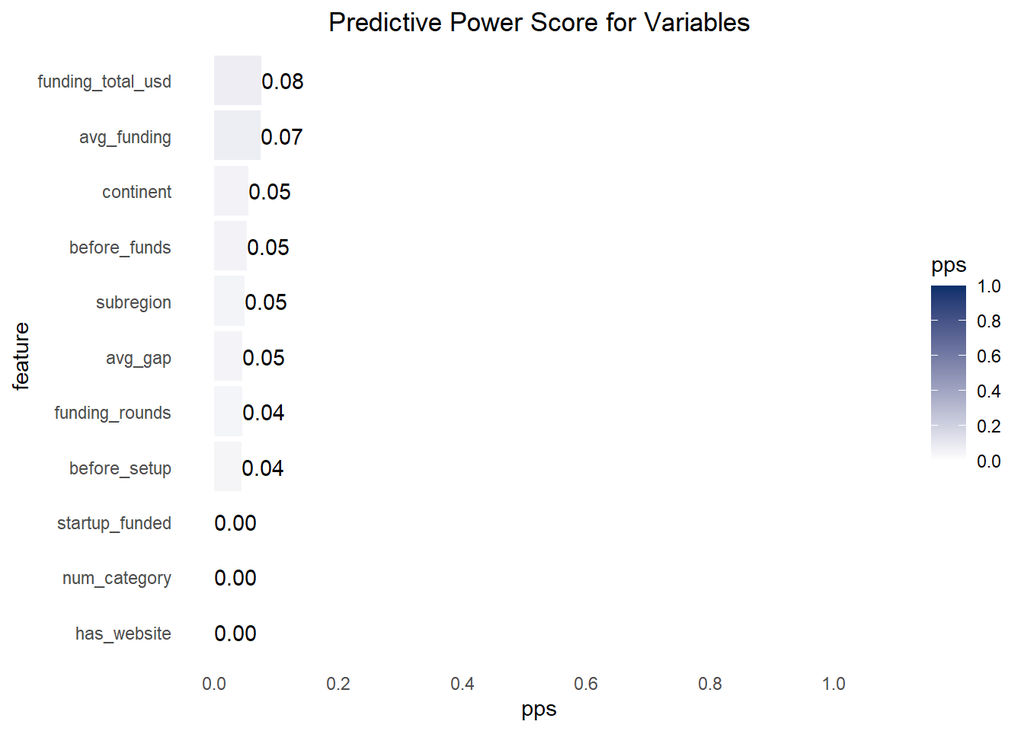

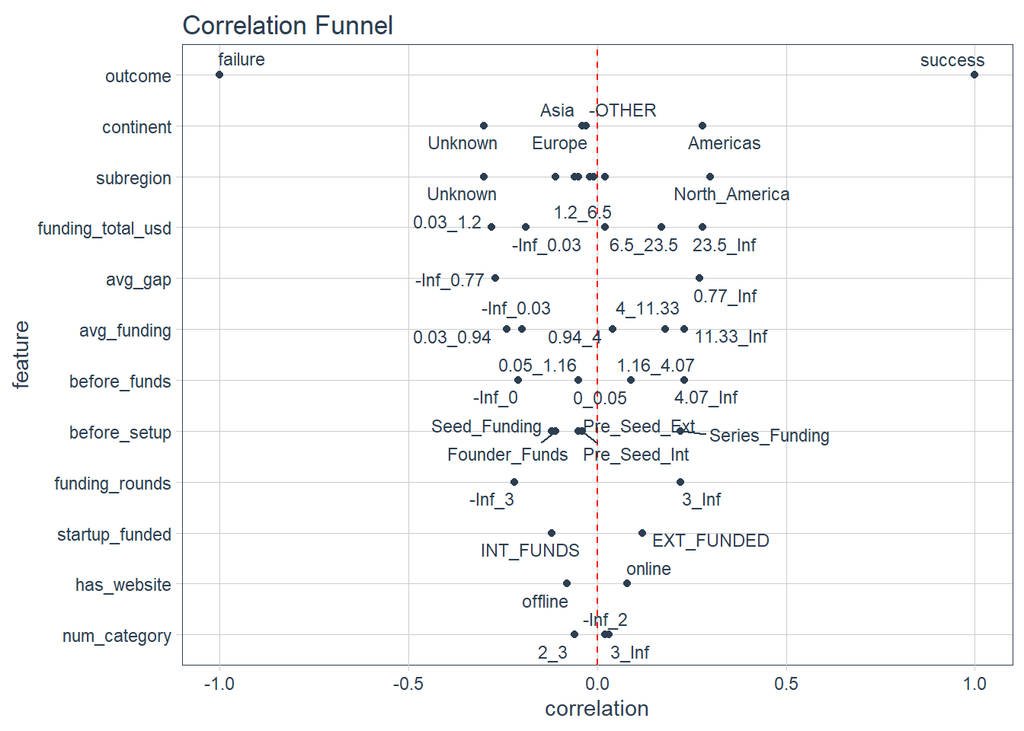

Insights from the Correlation Analysis:

In conclusion, this correlation analysis has provided valuable insights into the factors influencing startup success. It highlights the importance of geography, funding amounts, funding round frequency, maturity before seeking funding, and the stage of funding in determining a startup’s trajectory towards success. These findings can inform strategic decision-making and investment considerations for stakeholders in the startup ecosystem.

## Feature Engineering

**Business Category**

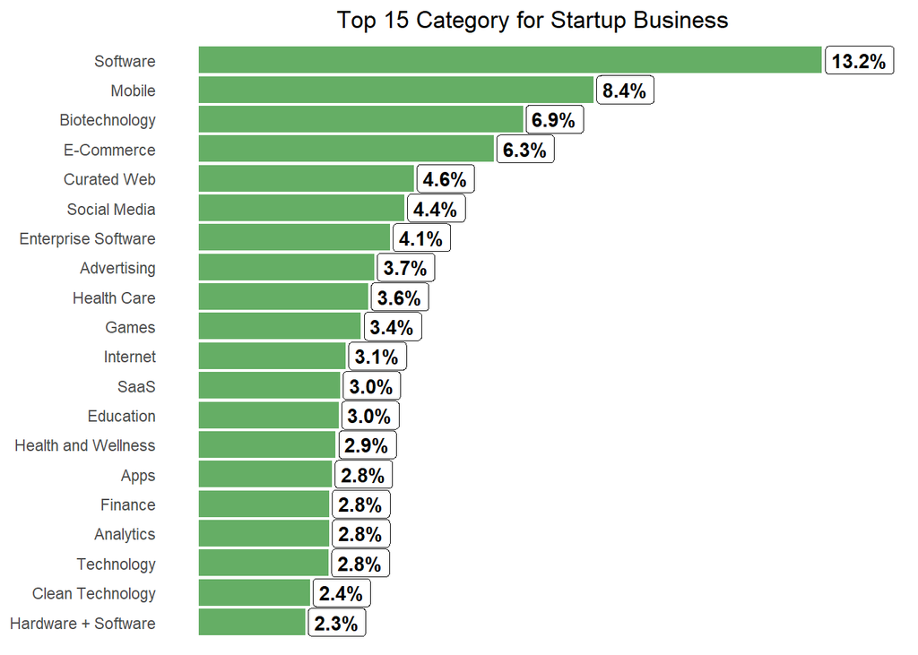

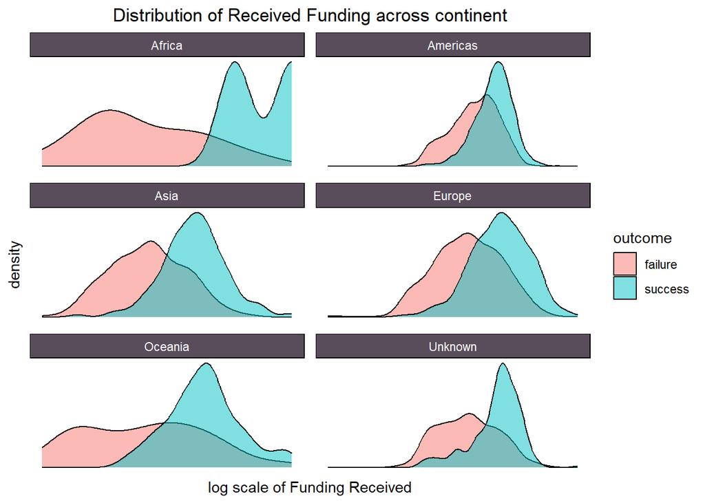

**New Features**

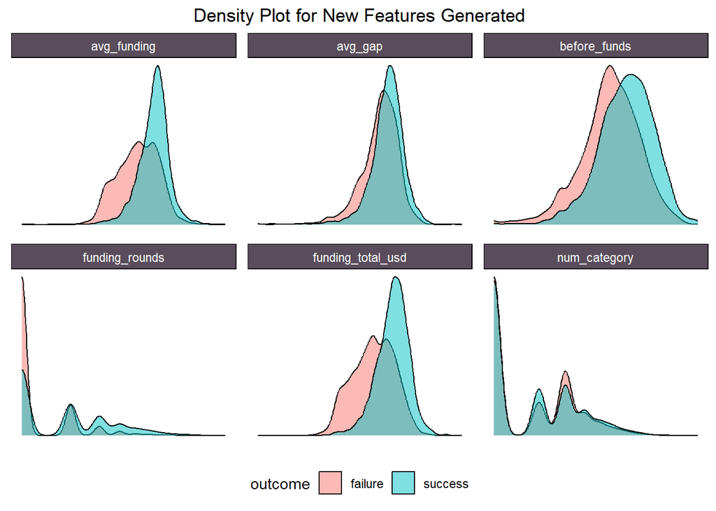

## Modeling Building

In this project, a rigorous optimization of our classification model’s performance was condected. I began by generating a 10-fold cross-validation dataset from our original training dataset. The model building process was carried out using the tidymodel suite of packages, which facilitated the creation of multiple candidate models. The models under consideration encompassed logistic regression, random forest, XGBoost, and LightGBM.

To determine the most effective model, efficient grid search via racing with repeated measure ANOVA was utilized to meticulously fine-tuned each candidate model. Below, we present a comprehensive summary of the results obtained from the model performance evaluation:

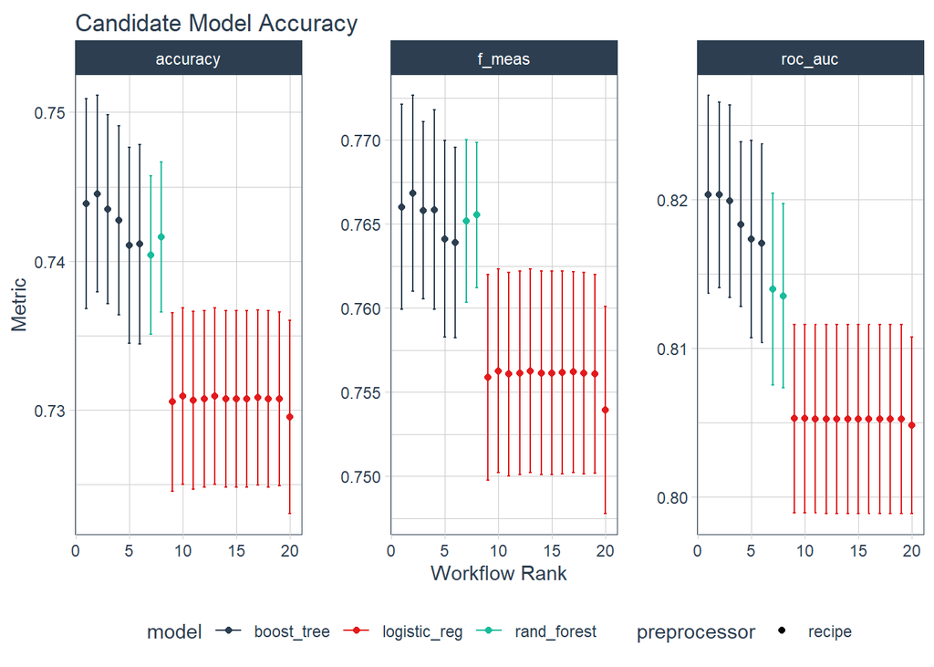

Top 10 Models base on ROC_AUC metric

| model | wflow_id | .config | .metric | roc_auc | std_err | rank |
| --- | --- | --- | --- | --- | --- | --- |
| boost_tree | xgboost | Preprocessor1_Model04 | roc_auc | 0.820 | 0.004 | 1 |
| boost_tree | xgboost | Preprocessor1_Model03 | roc_auc | 0.820 | 0.004 | 2 |
| boost_tree | xgboost | Preprocessor1_Model13 | roc_auc | 0.820 | 0.004 | 3 |
| boost_tree | lightgbm | Preprocessor1_Model01 | roc_auc | 0.818 | 0.003 | 4 |
| boost_tree | lightgbm | Preprocessor1_Model09 | roc_auc | 0.817 | 0.004 | 5 |
| boost_tree | lightgbm | Preprocessor1_Model14 | roc_auc | 0.817 | 0.004 | 6 |
| rand_forest | ranger | Preprocessor1_Model07 | roc_auc | 0.814 | 0.004 | 7 |
| rand_forest | ranger | Preprocessor1_Model08 | roc_auc | 0.814 | 0.004 | 8 |
| logistic_reg | logistic | Preprocessor1_Model06 | roc_auc | 0.805 | 0.004 | 9 |
| logistic_reg | logistic | Preprocessor1_Model15 | roc_auc | 0.805 | 0.004 | 10 |

### Ensemble Model

Aiming to enhance the predictive capabilities of our classification model, I strategically pursued a stacking ensemble modeling approach, resulting in a notable advancement in performance. Through meticulous evaluation and refinement, the final model achieved an impressive ROC-AUC metric of 87%. The visualization provided in the accompanying chart offers comprehensive insights into our discoveries, showcasing the substantial performance gains attained through this iterative process.

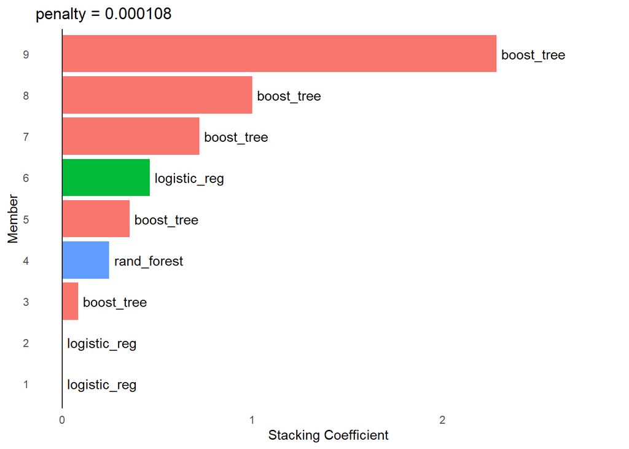

Figure 3: Candidate Model choose after ensemble stacking

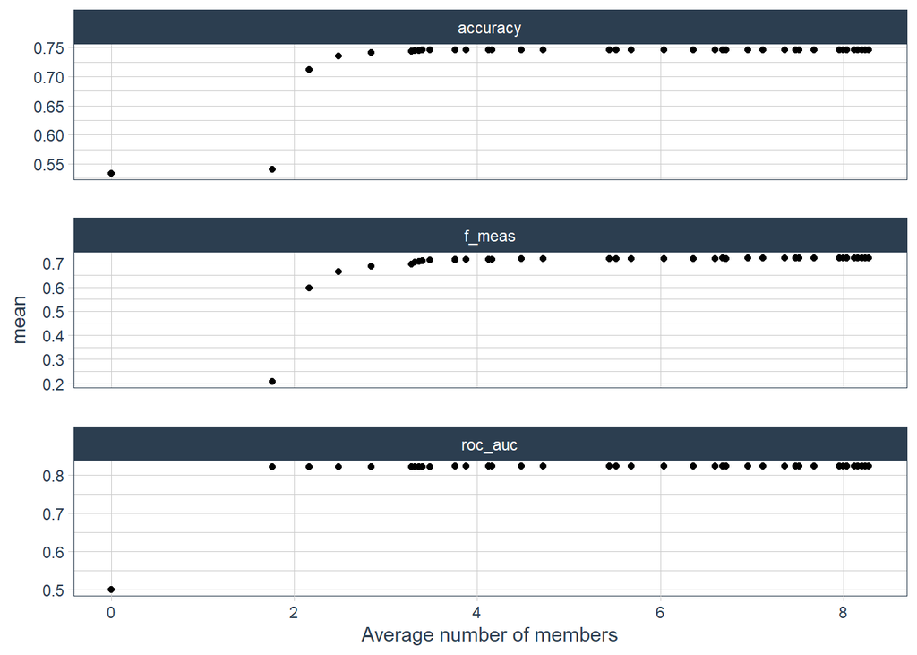

## Model Diagnostics

Model Performance on test dataset

| Model | accuracy | roc_auc | precision | recall | pr_auc |
| --- | --- | --- | --- | --- | --- |
| binary | 0.784 | 0.871 | 0.785 | 0.818 | 0.882 |

Based on the lift chart analysis, it is evident that our classification model demonstrates significant predictive capability for startup success, particularly in the highest deciles. Throughout the deciles, the uplift value surpasses 1, indicating superior performance compared to a random model, not only for likely cases but also for unlikely cases. This suggests that our model exhibits strong discriminative power in distinguishing between successful and unsuccessful startups.

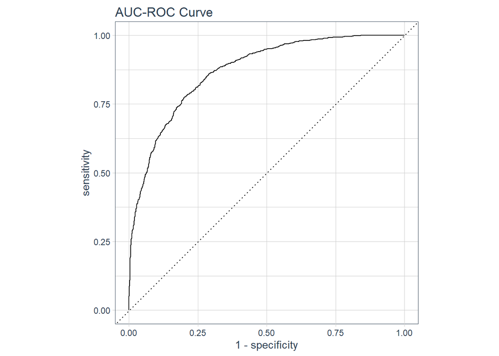

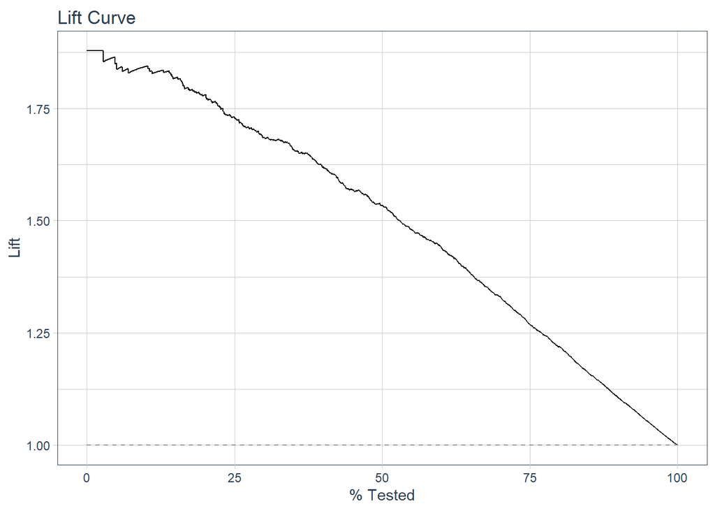

The following report presents an analysis of our classification model’s performance on the test dataset. By employing our model strategy, we can effectively target and capture 86% of successful startups while focusing on 60% of the startup population. This information allows us to make well-informed decisions regarding investment opportunities in startups, considering the probability of success within each decile and accounting for the expected error ranges. Such insights enhance our ability to optimize investment allocation and maximize potential returns.

Model Performance on Test dataset

| Decile | Companies | Avg_Funding | Actual | Predicted | Probability | Error_Rate | Prob_Mean | Prob_Std |
| --- | --- | --- | --- | --- | --- | --- | --- | --- |
| 1 | 267 | 157,729,257 | 262 | 267 | 87%-92% | 8%-13% | 0.893 | 0.013 |
| 2 | 267 | 60,073,965 | 244 | 267 | 83%-87% | 13%-17% | 0.854 | 0.011 |
| 3 | 267 | 27,526,969 | 213 | 267 | 78%-83% | 17%-22% | 0.807 | 0.016 |
| 4 | 267 | 21,422,378 | 202 | 267 | 69%-78% | 22%-31% | 0.739 | 0.025 |
| 5 | 267 | 10,504,965 | 169 | 267 | 57%-69% | 31%-43% | 0.631 | 0.035 |
| 6 | 267 | 5,230,024 | 137 | 145 | 45%-57% | 43%-55% | 0.505 | 0.035 |
| 7 | 267 | 3,701,585 | 96 | 0 | 33%-45% | 55%-67% | 0.388 | 0.035 |
| 8 | 267 | 3,437,961 | 63 | 0 | 20%-33% | 67%-80% | 0.260 | 0.037 |
| 9 | 266 | 2,755,661 | 27 | 0 | 12%-20% | 80%-88% | 0.157 | 0.025 |
| 10 | 266 | 1,976,494 | 7 | 0 | 8%-12% | 88%-92% | 0.099 | 0.010 |

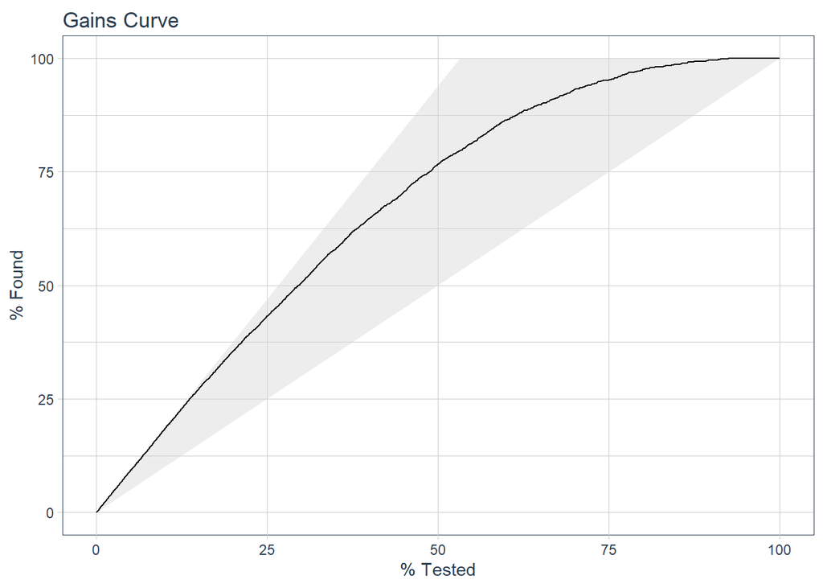

## Model Interpretation

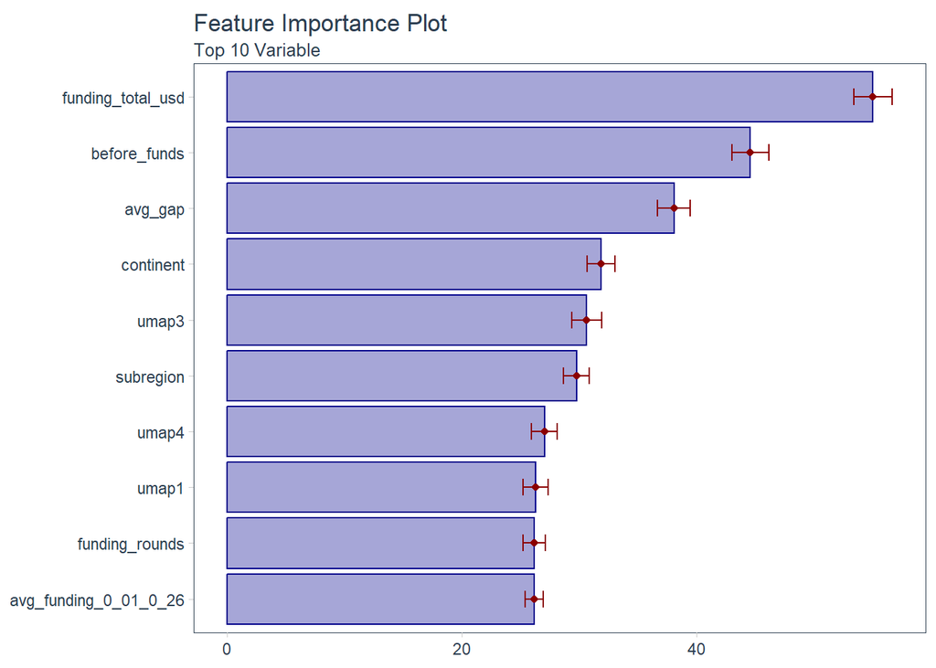

Based on the chart analysis, we have identified meaningful insights regarding the relationship between funding and startup success. The findings suggest a clear positive correlation between the amount of funding and the probability of a startup’s success. Specifically, as funding increases, the likelihood of success also tends to rise.  
Furthermore, we observed an interesting pattern concerning the number of funding rounds. Startups experience a significant boost in their probability of success when they go through their first three rounds of funding. However, beyond three rounds, the increase in success becomes less pronounced, indicating diminishing returns with each additional funding round.

These insights offer valuable implications for business decision-making. To increase the likelihood of success, companies should consider securing adequate funding, especially during the early stages. Moreover, understanding the optimal timing for funding rounds can help startups allocate their resources efficiently, maximizing the potential for growth and success.

It is essential to note that these findings are based on an explainable model analysis and should be taken into consideration alongside other factors that may influence startup success, such as market conditions, industry trends, and the effectiveness of the business strategy. Nonetheless, this analysis provides a valuable starting point for making data-driven decisions to support startup growth and success.

### Predictor-Response Relationship

The analysis of our partial dependence profile plot reveals valuable insights into the factors influencing the success of business startups. It demonstrates a positive correlation between the amount of funding secured and the likelihood of success. As funding increases, the chances of success also rise, indicating the importance of financial support in driving startup achievements.

Moreover, we observe a significant impact on success rates with regards to the number of funding rounds. Startups experience a substantial increase in their likelihood of success as they progress from one to three funding rounds. However, beyond three rounds, there appears to be diminishing returns, suggesting that further funding rounds may not significantly contribute to success.

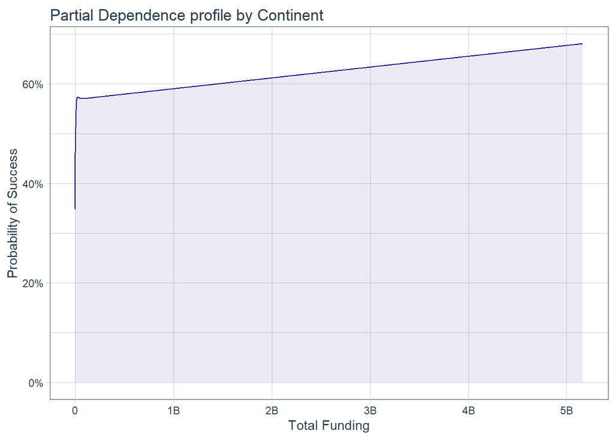

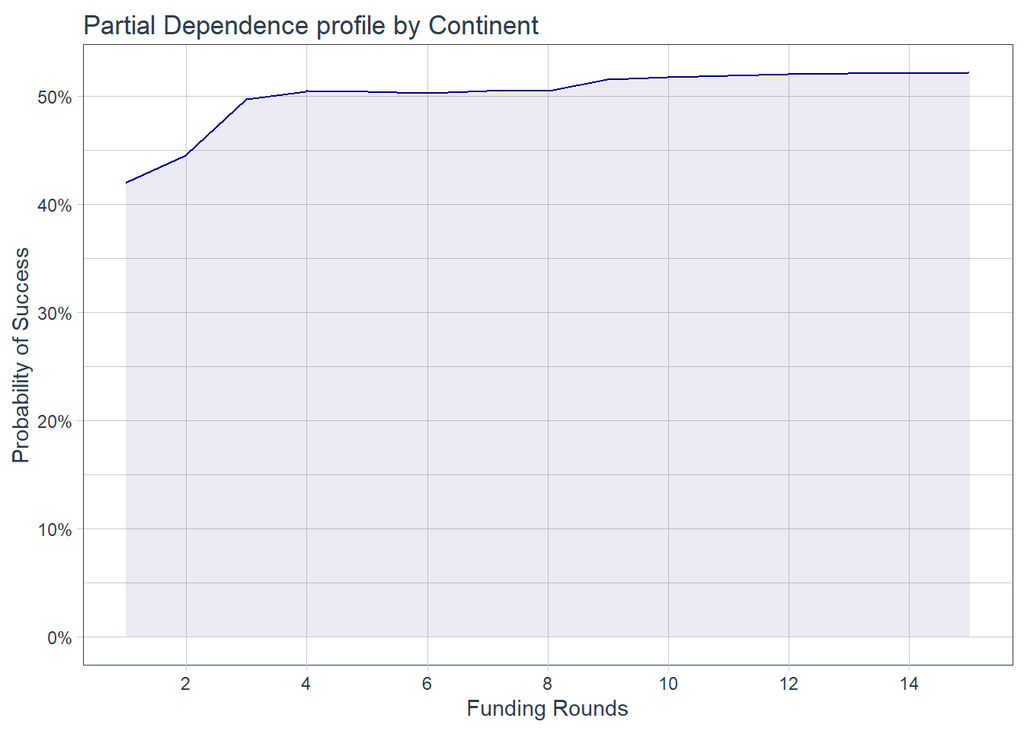

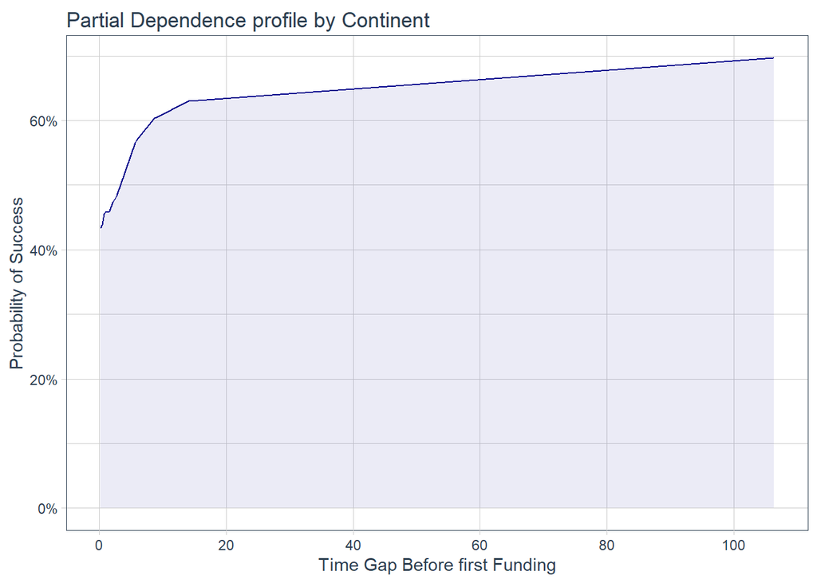

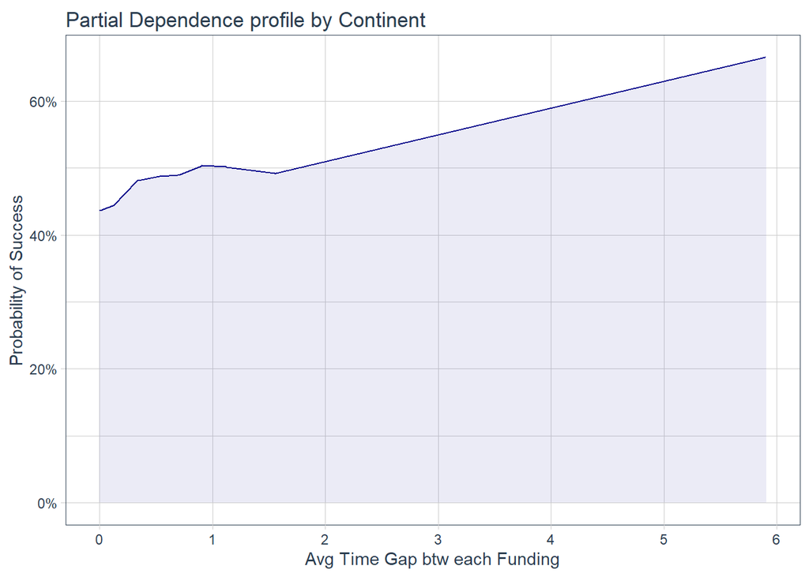

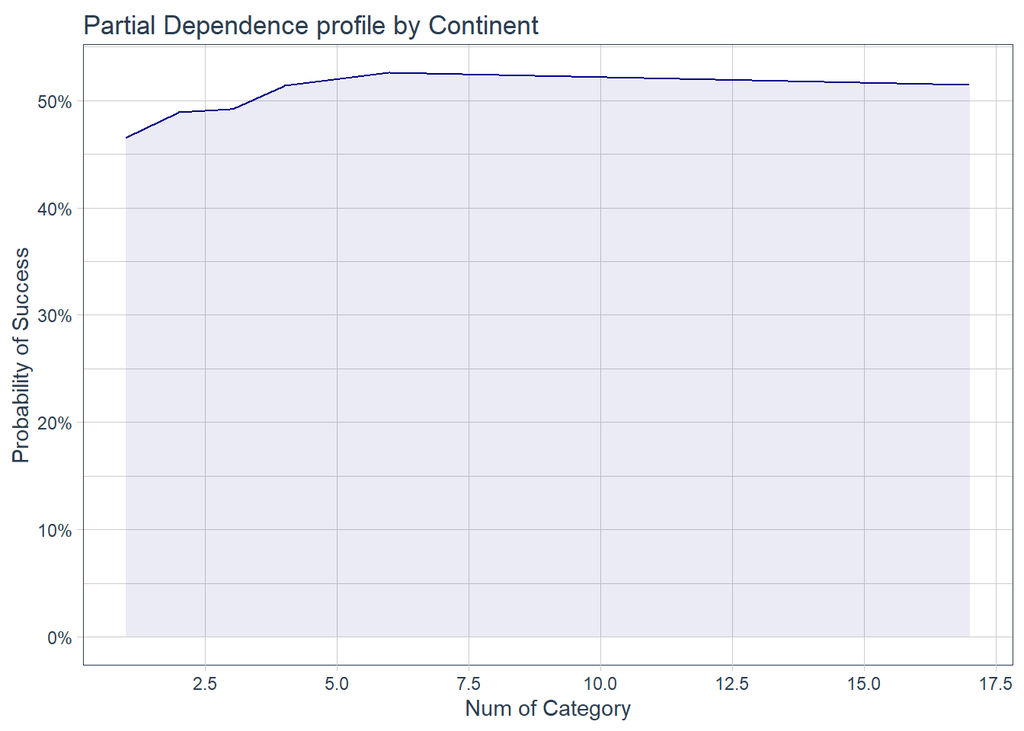

Overall, this analysis highlights the crucial role of funding amounts, the number of funding rounds, and the timing of initial funding in determining the success of business startups. Understanding these relationships can help entrepreneurs and investors make more informed decisions and increase the chances of startup success.

**Total Funding**

After conducting an in-depth analysis of startup failures, our reports reveal intriguing insights. Surprisingly, even at zero funding levels, businesses in America, Europe, and Asia exhibit a notably higher likelihood of success compared to other regions. Particularly, startups in South East Asia demonstrate the highest success rate among all countries.

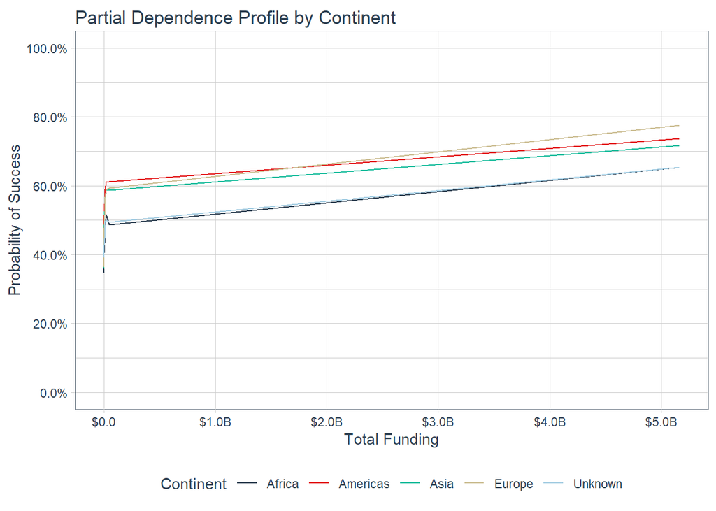

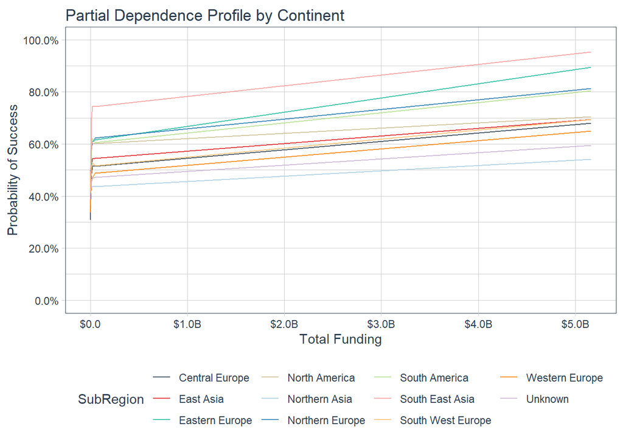

Another compelling observation is that startups backed by series funding experience a significantly higher probability of success. This underscores the crucial role that funding plays in bolstering a startup’s chances of survival and growth in today’s competitive landscape.

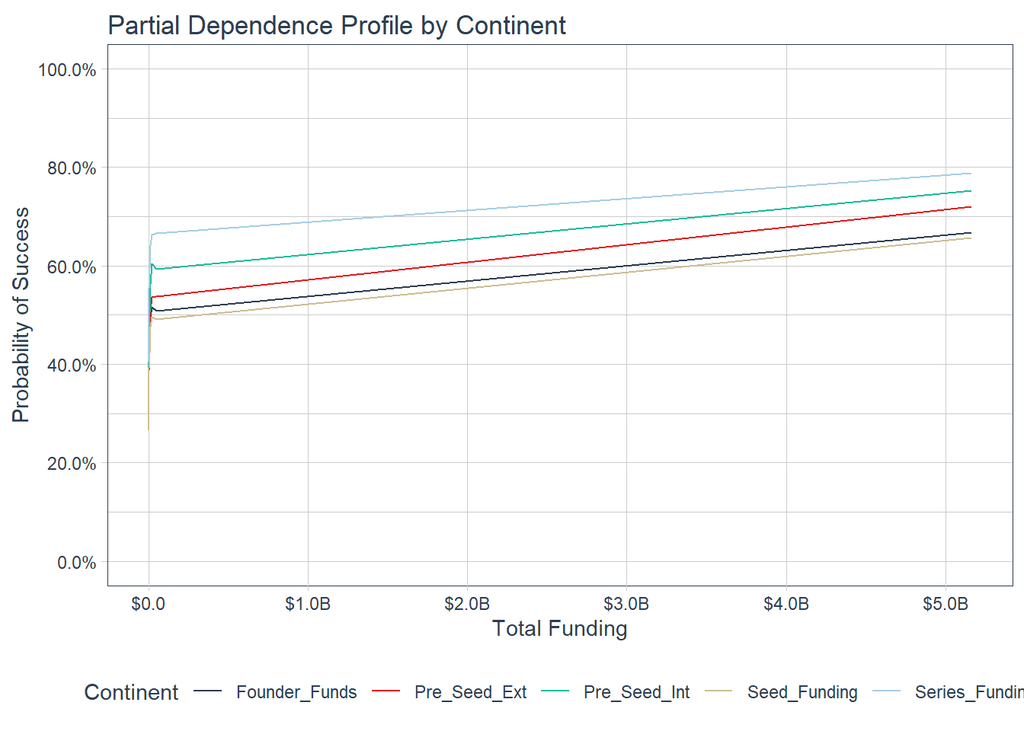

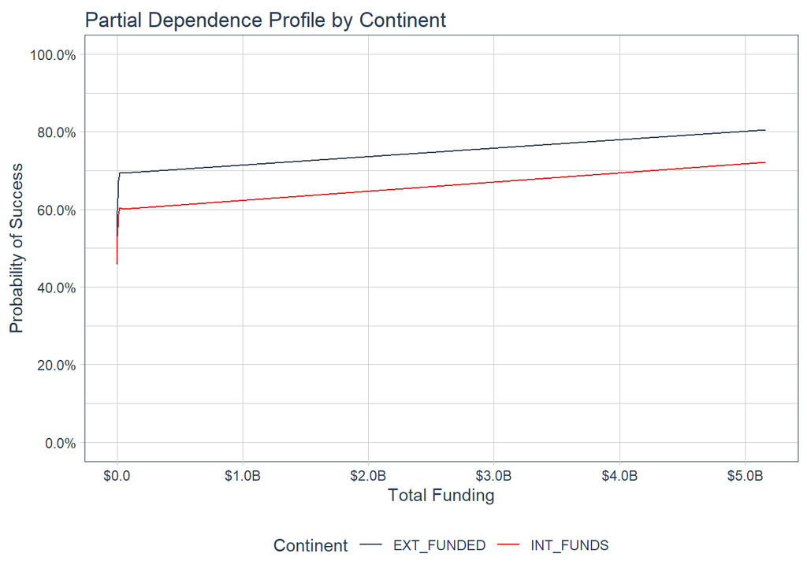

These findings shed light on the intricate dynamics behind startup success and offer valuable guidance for aspiring entrepreneurs and investors alike. Understanding the regional variations and the impact of funding stages is critical for making informed decisions and fostering a thriving startup ecosystem.

**Funding Rounds**

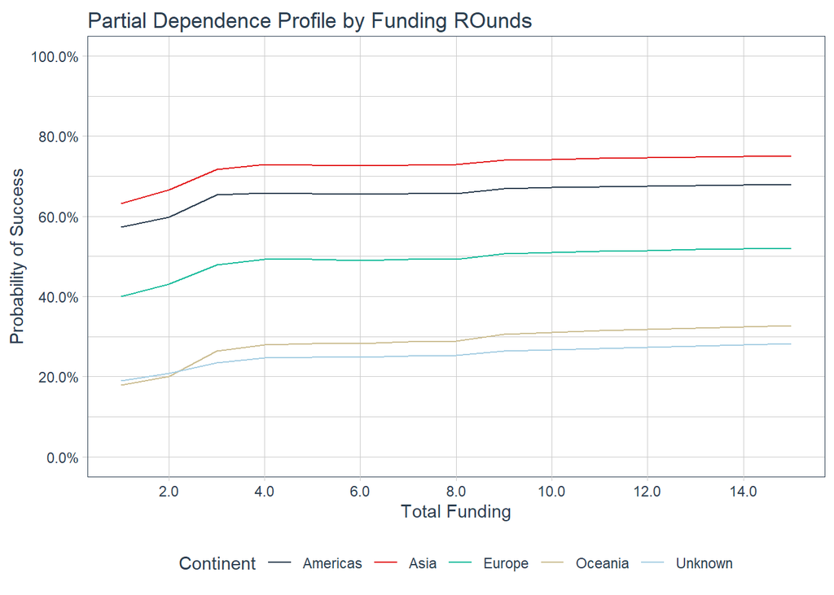

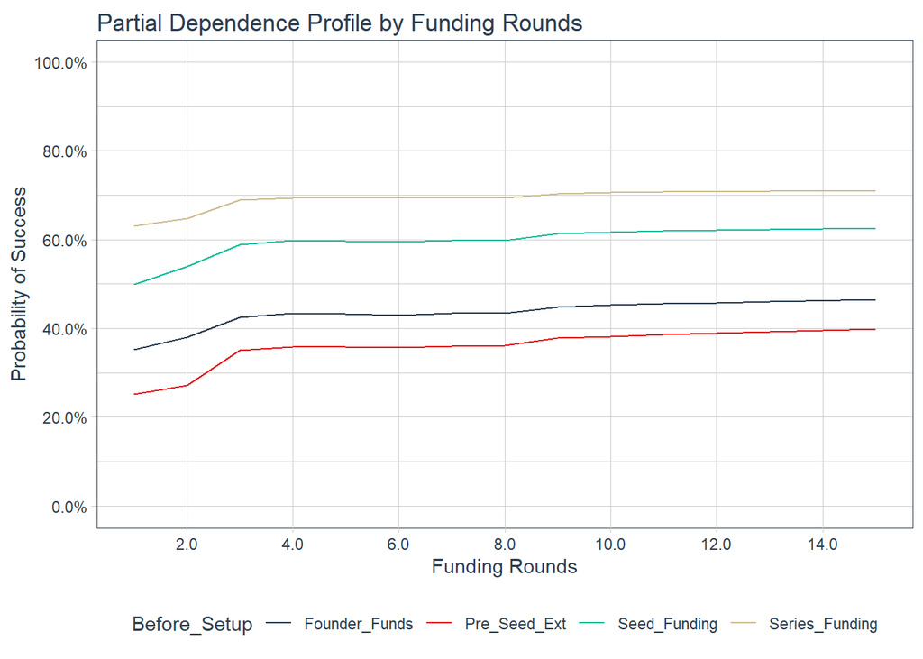

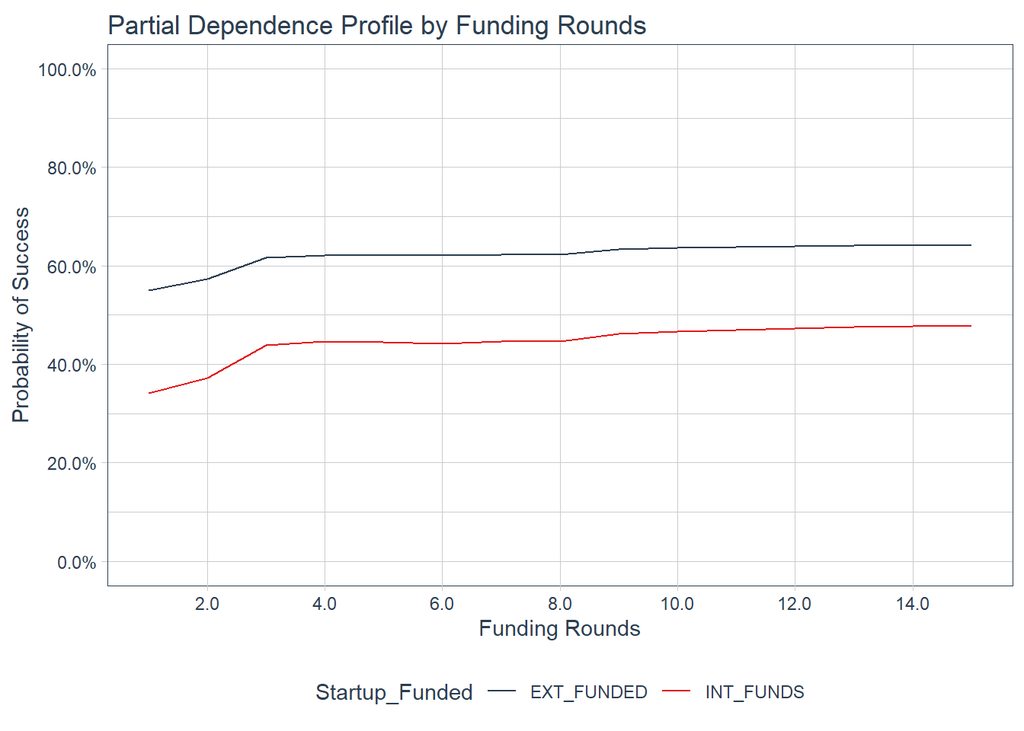

**Before Funds**

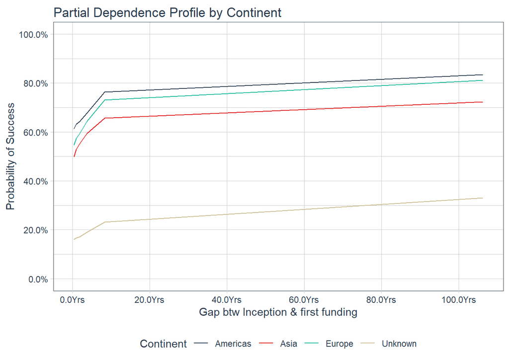

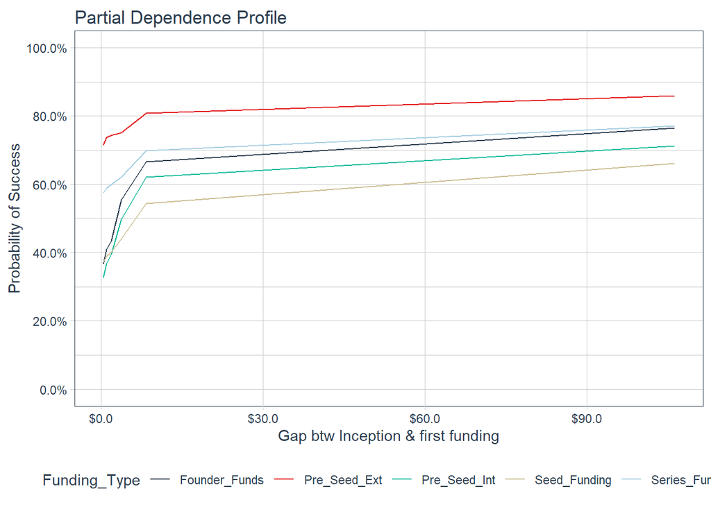

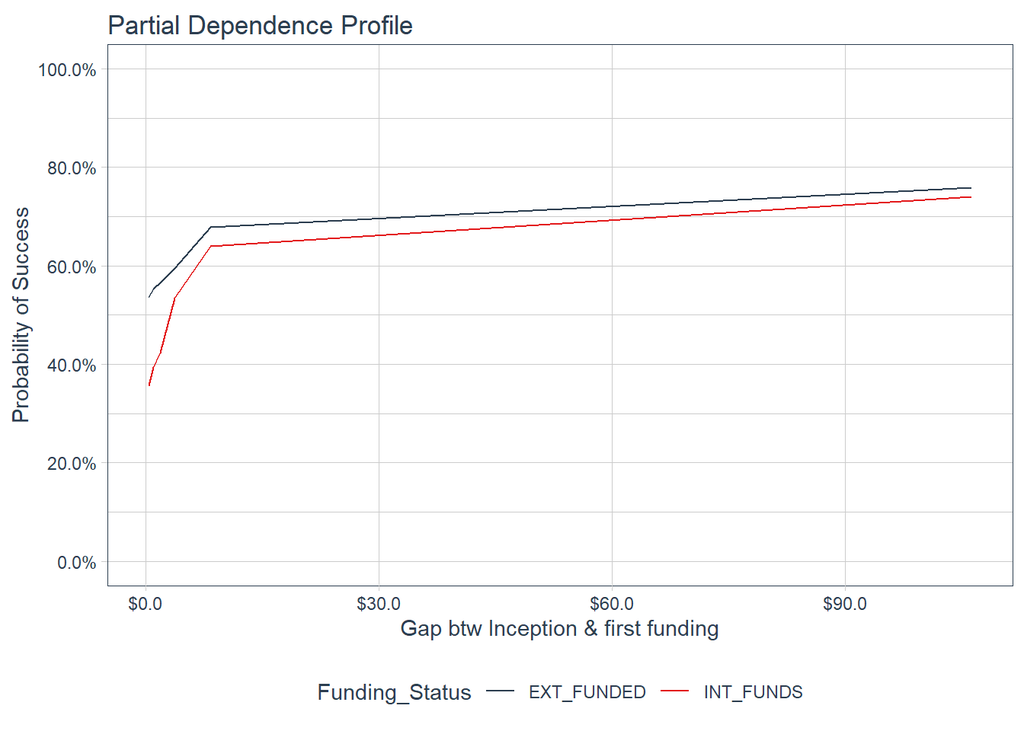

## How many Startups Businesses would succeed or fail?

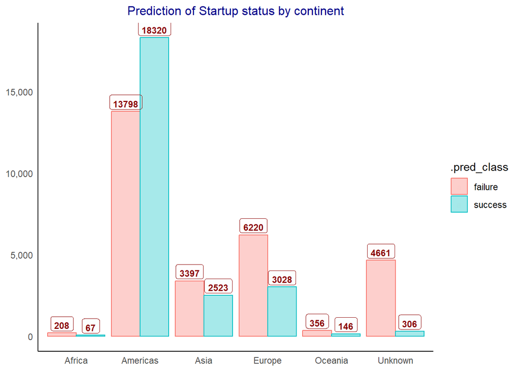

This higher success rate for startups in this continent suggests that there might be favorable business conditions or market dynamics in these regions that contribute to their prosperity. Companies looking to invest or expand their operations should consider these regions as potential lucrative markets.  
Furthermore, the PDP plot reveals that even without external funding, startups in this continents exhibit a higher likelihood of success than those in other continents. This implies the presence of inherent strengths or conducive factors in these regions, such as a robust entrepreneurial ecosystem, supportive regulatory frameworks, or strong market demand for innovative products or services.

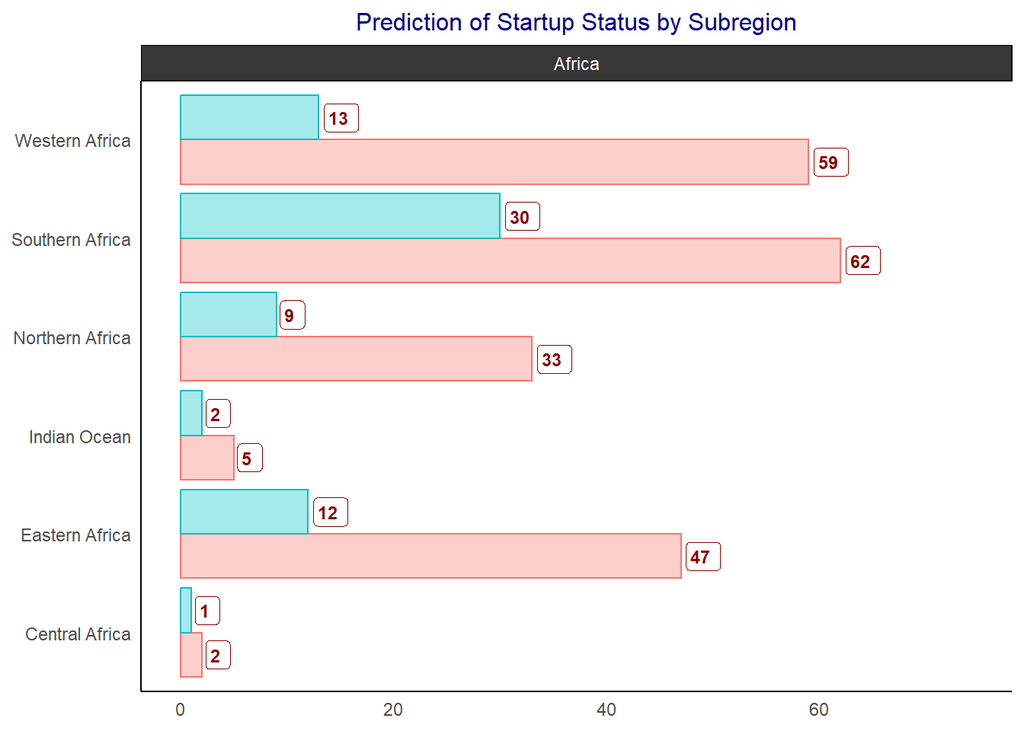

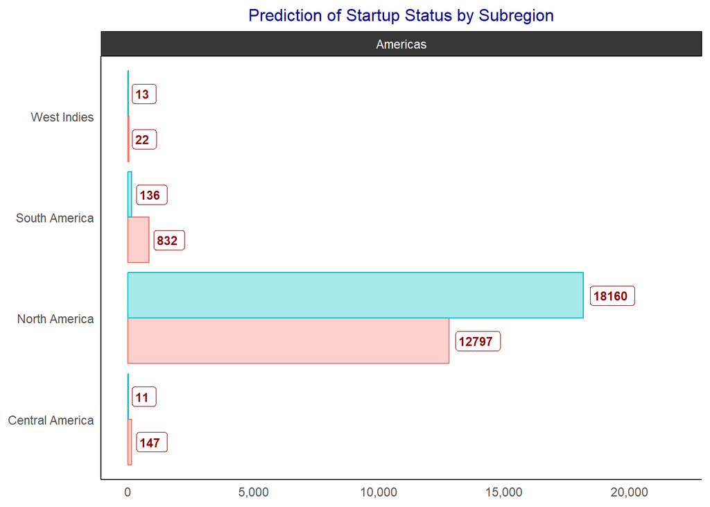